# Uso de IA, sueño y rendimiento académico en estudiantes de UTEC

- Mostrar todo el código
- Ocultar todo el código
- Ver el código fuente

PG2 — Informe | Estadística y Probabilidades, sección 01, ciclo 2026-2

Autor/a

S1-G6

Fecha de publicación

15 de noviembre de 2026

# 1 Introducción

## 1.1 Relevancia

Este tema es importante porque la mayoría de estudiantes usa la IA diariamente para sus actividades académicas. Analizar este uso nos ayuda a saber con qué frecuencia la utilizan, para qué la usan y en qué cursos hacen más consultas. También nos permite ver si el uso de esta herramienta realmente les ayuda a comprender mejor los temas o a ahorrar tiempo. Además, consideraremos otros factores asociados a hábitos de los estudiantes, como las horas de sueño y horas efectivas de estudio, para determinar su influencia en el rendimiento académico.

## 1.2 Planificación

### 1.2.1 Diagrama de Gantt

**Código**

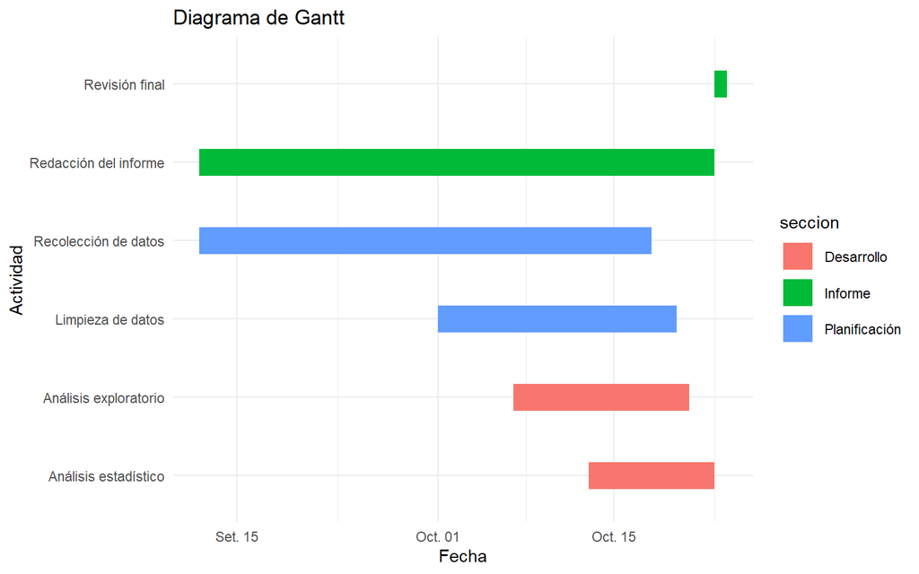

```r
library(readr)
library(dplyr)
library(tidyverse)
library(ggplot2)

tareas <- data.frame(
  tarea = c(
    "Recolección de datos",
    "Limpieza de datos",
    "Análisis exploratorio",
    "Análisis estadístico",
    "Redacción del informe",
    "Revisión final"
  ),
  inicio = as.Date(c(
    "2026-09-12", "2026-10-01", "2026-10-07", "2026-10-13", "2026-09-12", "2026-10-23"
  )),
  fin = as.Date(c(
    "2026-10-18", "2026-10-20", "2026-10-21", "2026-10-23", "2026-10-23", "2026-10-24"
  )),
  seccion = c(
    "Planificación",
    "Planificación",
    "Desarrollo",
    "Desarrollo",
    "Informe",
    "Informe"
  )
)

ggplot(tareas,
       aes(x = inicio,
           xend = fin,
           y = tarea,
           yend = tarea,
           color = seccion)) +
  geom_segment(linewidth = 8) +
  labs(title = "Diagrama de Gantt",
       x = "Fecha",
       y = "Actividad") +
  theme_minimal()
```

## 1.3 Objetivos

### 1.3.1 Objetivo general

Analizar el impacto de las horas de sueño y el uso de IA en el rendimiento académico de los estudiantes UTEC de Estadística sección 1 durante el ciclo 2026-2.

### 1.3.2 Objetivos específicos

1. Analizar la existencia de alguna relación entre la frecuencia diaria de consultas a la IA y el Nivel de satisfacción con el avance académico diario.
2. Analizar si existe alguna correlación entre el número de consultas a la IA en un cierto día y la cantidad de horas dedicadas al estudio.
3. Identificar si el curso de mayor consulta influye en el principal uso que se le da a la Inteligencia Artificial ese día y determinar qué usos generan mayor número de tareas con tiempo ahorrado.
4. Determinar si existe una relación entre las horas de sueño de la noche anterior y el nivel de comprensión de las actividades académicas realizadas durante el día.

# 2 Datos

## 2.1 Población objetivo

Estudiantes universitarios de UTEC durante el semestre 2026-2 que cursan Estadística y Probabilidades de la sección 01.

### 2.1.1 Unidad muestral

Conformada por los estudiantes universitarios evaluados de forma individual y diaria. A cada uno de ellos se le aplicará un registro de datos para medir su comportamiento diario, su rendimiento académico y su relación con el uso de IA (en la tabla principal).

### 2.1.2 Representatividad de la muestra

Con la finalidad de que la muestra obtenida refleje a la población y se minimicen posibles sesgos, se plantean las siguientes medidas:

Cobertura total de la sección: El instrumento de medición se aplicará en un aula específica, de modo que todos los integrantes contarán con acceso diario al formulario, evitando el sesgo de no respuesta

Medición al cierre del día: El cuestionario se realizará al final de cada día, lo cual permitirá registrar las variables diarias atenuando el sesgo de memoria. El registro de un día se contará como válido si este se hace después de las 9:30 p.m. pero antes de la medianoche.

## 2.2 Tipo de muestreo

Se utilizará un muestreo sistemático por conveniencia, estructurado bajo un diseño de recolección de datos de tipo longitudinal. Esta decisión responde a la exigencia del estudio, el cual requiere que los estudiantes reporten sus métricas académicas, de sueño y de uso de IA de forma diaria. El diseño longitudinal genera observaciones repetidas por estudiante, lo que permite capturar patrones de comportamiento en el tiempo.

## 2.3 Recolección de datos

Se recolecta la información desde un formulario diario en Google Forms. Enlace: [formulario diario](https://docs.google.com/forms/d/e/1FAIpQLSf9LZ3tyLEgC4oDca7NH8S9Zh-StC2w6ukAMH6yRnJej6tVzQ/viewform).

## 2.4 Variables

### 2.4.1 Consideración de los tipos de variables

| Variable | Tipo general | Subtipo |
| --- | --- | --- |
| N° de consultas a IA realizadas ese día | Cuantitativa | Discreta |
| Principal uso de IA ese día | Cualitativa | Nominal |
| Nivel de satisfacción con el avance académico diario | Cualitativa | Ordinal |
| N° de tareas ese día en las que usar IA le ahorró tiempo | Cuantitativa | Discreta |
| curso sobre el cual se hicieron la mayoría de consultas de IA | Cualitativa | Nominal |
| Suma de horas efectivas de estudio | Cuantitativa | Continua |
| Horas de sueño de la noche anterior | Cuantitativa | Continua |
| Nivel de comprensión de las actividades académicas realizadas ese día | Cualitativa | Ordinal |

### 2.4.2 Libreta de códigos

| Variable | Restricción / Rango o categorías válidas |
| --- | --- |
| N° consultas a IA realizada ese día | x >= 0 |
| Nivel de satisfacción con el avance académico diario | Likert de 5 niveles, codificado de 1 a 5 |
| Suma de horas efectivas de estudio | x >= 0 |
| curso sobre el cual se hicieron la mayoría de consultas de IA | Código de curso UTEC, formato XX#### |
| Principal uso de IA ese día | resumir, resolver ejercicios, redactar, programar, otros |
| N° de tareas ese día en las que usar IA le ahorró tiempo | x >= 0 |
| Horas de sueño de la noche anterior | 0 <= x <= 24 |
| Nivel de comprensión de las actividades académicas realizadas ese día | Muy bajo, Bajo, Moderado, Alto, Muy alto |

### 2.4.3 Mediciones

Cada variable será registrada en el formulario de Google Forms, el cual contendrá todas las restricciones de valores dependiendo del tipo y naturaleza de la variable.

# 3 Limpieza de datos

Como ya se explicó esta parte en la primera entrega, solo se hará uso de 1 csv previamente exportados (`DF3` tiene la tabla prolija).

**Código**

```r
DF3<-read_csv("DF3.csv")
DF3$comprension <- factor(DF3$comprension,
                          levels = c("Muy bajo", "Bajo", "Moderado", "Alto", "Muy alto"),
                          ordered = TRUE)
```

# 4 Análisis descriptivo

## 4.1 Análisis univariado

### 4.1.1 Número de consultas a la IA

**Código**

```r
sd(DF3$consultas, na.rm = T) / abs(mean(DF3$consultas, na.rm = T))
```

```
[1] 1.069485
```

Dado un CV > 0.6, usaremos la mediana y los cuantiles para el análisis.

**Código**

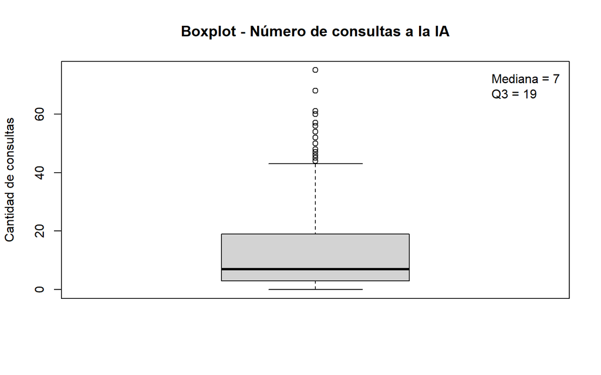

```r
boxplot(DF3$consultas,
        main = "Boxplot - Número de consultas a la IA",
        ylab = "Cantidad de consultas")
legend("topright",
       legend = paste("Mediana =", median(DF3$consultas, na.rm = TRUE), "\nQ3 =", quantile(DF3$consultas, 0.75, na.rm = T, type = 3)), bty = "n")
```

En al menos la mitad de los registros, el estudiante hace 7 o más consultas diarias a la IA, lo que indica un uso frecuente de esta herramienta. Esto se ve reforzado al notar que, en por lo menos 25% de los registros, los estudiantes han hecho 19 o más consultas diarias a la IA.

**Código**

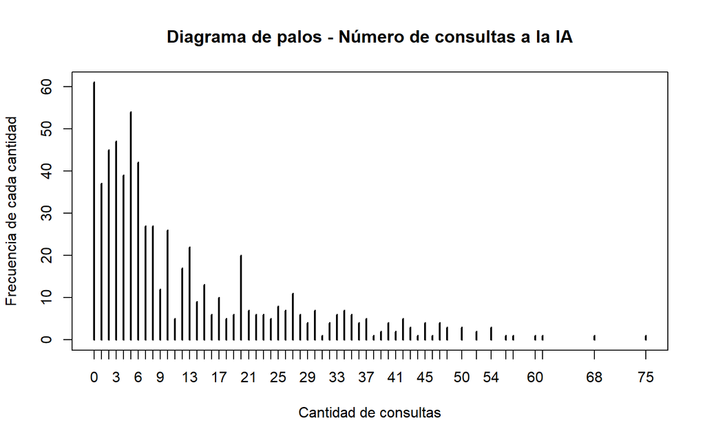

```r
plot(table(DF3$consultas),
        main = "Diagrama de palos - Número de consultas a la IA",
        xlab = "Cantidad de consultas",
        ylab = "Frecuencia de cada cantidad")
```

### 4.1.2 Nivel de comprensión

Al ser ordinal, usamos frecuencias, porcentajes y barras. No hay media ni desviación porque no son números, pero sí mediana porque tienen orden.

**Código**

```r
table(DF3$comprension)
```

```
Muy bajo     Bajo Moderado     Alto Muy alto
      28       56      386      151       53
```

**Código**

```r
round(prop.table(table(DF3$comprension)) * 100, 2)
```

```
Muy bajo     Bajo Moderado     Alto Muy alto
    4.15     8.31    57.27    22.40     7.86
```

**Código**

```r
round(cumsum(prop.table(table(DF3$comprension))) * 100, 2)
```

```
Muy bajo     Bajo Moderado     Alto Muy alto
    4.15    12.46    69.73    92.14   100.00
```

La moda y la mediana son Moderado (57.27%; el acumulado pasa el 50% ahí con 69.73%). El 30.27% tuvo comprensión alta o muy alta y solo el 12.46% baja o muy baja.

**Código**

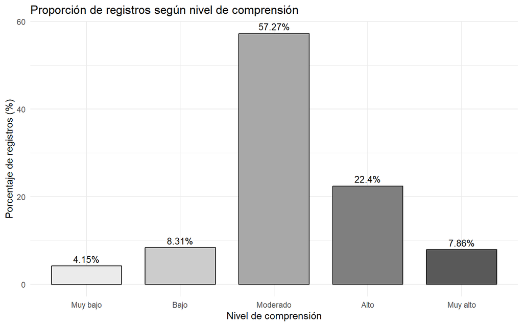

```r
DF3 %>%
  count(comprension) %>%
  mutate(p = n / sum(n) * 100) %>%
  ggplot(aes(x = comprension, y = p, fill = comprension)) +
  geom_col(color = "black", width = 0.75) +
  geom_text(aes(label = paste0(round(p, 2), "%")), vjust = -0.5, size = 3.5) +
  scale_fill_manual(values = c("gray92", "gray80", "gray66", "gray50", "gray35")) +
  labs(title = "Proporción de registros según nivel de comprensión",
       x = "Nivel de comprensión", y = "Porcentaje de registros (%)") +
  theme_minimal() +
  theme(legend.position = "none")
```

### 4.1.3 Horas de sueño

**Código**

```r
summary(DF3$sueno)
```

```
   Min. 1st Qu.  Median    Mean 3rd Qu.    Max.
    0.0     6.0     7.0     6.6     8.0    14.0
```

**Código**

```r
round(sd(DF3$sueno),2)
```

```
[1] 1.95
```

**Código**

```r
IQR(DF3$sueno)
```

```
[1] 2
```

**Código**

```r
round(sd(DF3$sueno) / mean(DF3$sueno),2) #CV
```

```
[1] 0.29
```

El coeficiente de variación es `0.29` por lo que tanto la media como la mediana representan bien el sueño de los estudiantes y al ser `sueno` una variable cuantitativa continua, se eligieron boxplot e histograma para describirla.

**Código**

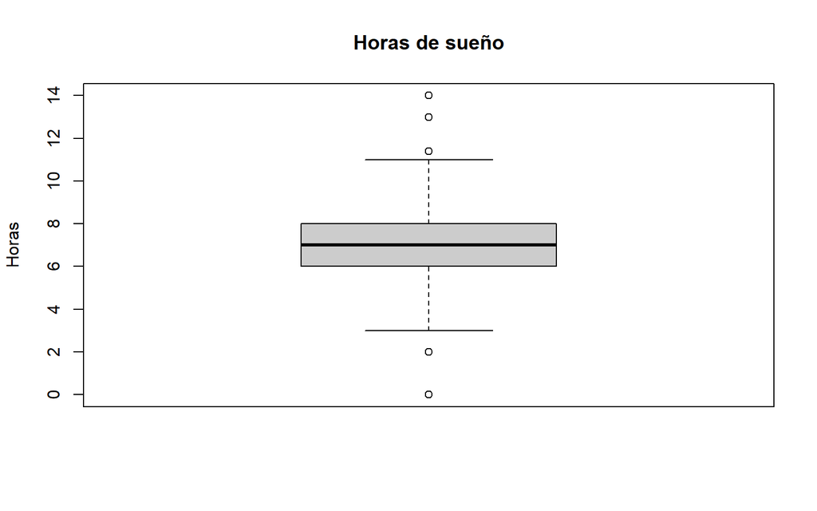

```r
boxplot(DF3$sueno,
        main = "Horas de sueño",
        ylab = "Horas",
        col = "gray80")
```

La variable `sueno` muestra un patrón equilibrado entre los estudiantes de UTEC: la mitad duerme 7 horas o menos, y el 50% central concentra su descanso entre las 6 y 8 horas.

**Código**

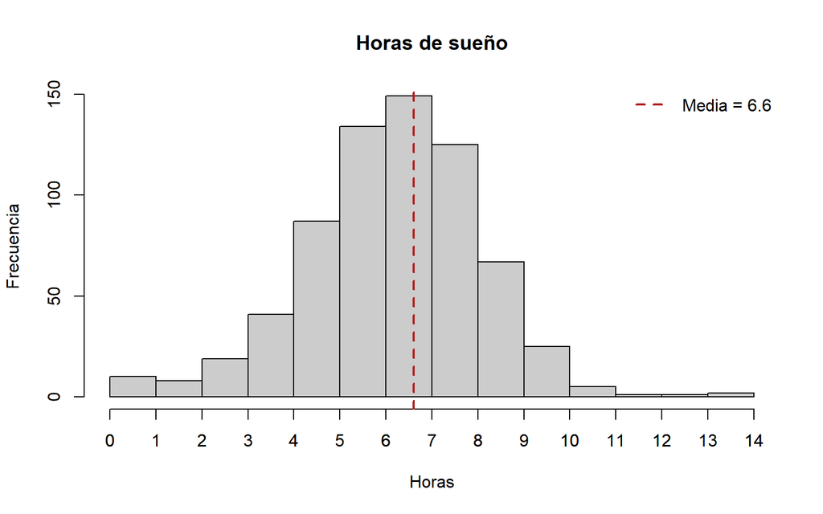

```r
hist(DF3$sueno,
     main = "Horas de sueño",
     xlab = "Horas",
     col = "gray80",
     ylab = "Frecuencia")
axis(1, at = 0:ceiling(max(DF3$sueno)))
abline(v = mean(DF3$sueno, na.rm = TRUE), col = "firebrick", lwd = 2, lty = 2)
legend("topright",
       legend = paste("Media =", round(mean(DF3$sueno, na.rm = TRUE), 2)),
       col = "firebrick", lty = 2, lwd = 2, bty = "n")
```

El histograma confirma ese equilibrio, la mayoría de los estudiantes duerme un número similar de horas, y son pocos los que se alejan bastante del resto.

## 4.2 Análisis de interacción

### 4.2.1 Objetivo 1: consultas vs. satisfacción

**Código**

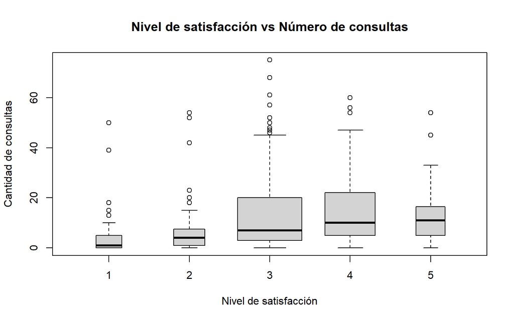

```r
boxplot(consultas ~ satisfaccion, data = DF3,
        main = "Nivel de satisfacción vs Número de consultas",
        xlab = "Nivel de satisfacción",
        ylab = "Cantidad de consultas",
        varwidth = T)
```

Se nota un claro incremento en la mediana de `consultas` de acuerdo al incremento del nivel de satisfacción. Esto indica que podría haber una relación importante entre el número de consultas a la IA y cuán satisfecho se está con el estudio de ese día.

**Código**

```r
quantile(DF3$consultas[DF3$satisfaccion == 3], 0.3, na.rm = T, type = 3)
```

```
30%
  4
```

**Código**

```r
quantile(DF3$consultas[DF3$satisfaccion == 4], 0.3, na.rm = T, type = 3)
```

```
30%
  5
```

**Código**

```r
quantile(DF3$consultas[DF3$satisfaccion == 5], 0.3, na.rm = T, type = 3)
```

```
30%
  6
```

Se puede notar que al menos el 70% de los registros de cada categoría de satisfacción “positiva” (3, 4, 5) incluye 4 o más consultas a la IA por día, reforzando la idea de una relación positiva entre `consultas` y `satisfacción`.

### 4.2.2 Objetivo 2: consultas vs. estudio

**Código**

```r
cor.test(DF3$consultas,DF3$estudio,method="spearman")
```

```
    Spearman's rank correlation rho

data:  DF3$consultas and DF3$estudio
S = 25663305, p-value < 2.2e-16
alternative hypothesis: true rho is not equal to 0
sample estimates:
     rho
0.497096
```

Se usó el coeficiente de correlación de Spearman debido a que resiste mejor la presencia de outliers, el cual fue de 0.497, lo que muestra una asociación positiva y moderada, además de que la prueba da un p-value < 0.001. Como hay registros repetidos por estudiante, ese valor debe interpretarse con cuidado. Hay una tendencia de que a mayor cantidad de horas de estudio habrá más consultas que se realizaron.

**Código**

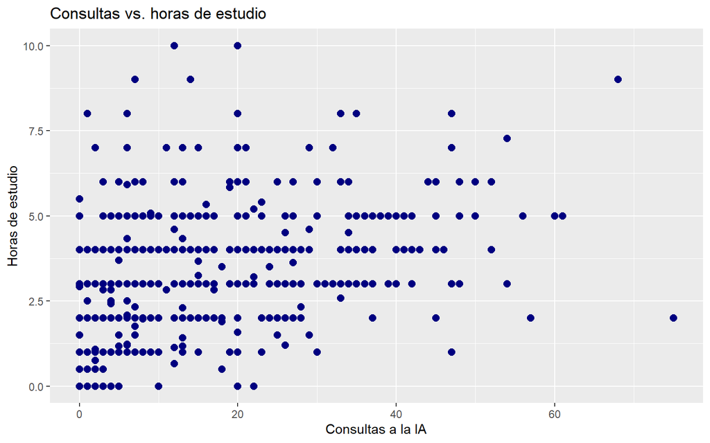

```r
ggplot(DF3, aes(x = consultas, y = estudio)) +
  geom_point(color = "navy", size = 2.5) +
  labs(
    title = "Consultas vs. horas de estudio",
    x = "Consultas a la IA",
    y = "Horas de estudio"
  )
```

### 4.2.3 Objetivo 3a: curso vs. uso

Al ser ambas nominales, usamos tabla cruzada, porcentajes por curso y barras apiladas al 100%. Quitamos los días sin uso de IA y dejamos los 4 cursos y 4 usos más frecuentes.

**Código**

```r
DFC <- DF3[DF3$uso_ia == "Usó IA", ]
DFC$curso <- toupper(DFC$curso)
DFC$uso <- as.character(DFC$uso)
DFC <- DFC[DFC$curso %in% c("CC1105", "CS2031", "CC2101", "CS2013"), ]
DFC <- DFC[DFC$uso %in% c("Resolver ejercicios", "Resumir", "Programar", "Redactar"), ]
nrow(DFC)
```

```
[1] 247
```

**Código**

```r
tabla <- table(DFC$curso, DFC$uso)
tabla
```

```
         Programar Redactar Resolver ejercicios Resumir
  CC1105        33        9                  31      15
  CC2101         2        2                  34      12
  CS2013        23        0                  12      16
  CS2031        34        1                   4      19
```

**Código**

```r
round(prop.table(tabla, 1) * 100, 2)
```

```
         Programar Redactar Resolver ejercicios Resumir
  CC1105     37.50    10.23               35.23   17.05
  CC2101      4.00     4.00               68.00   24.00
  CS2013     45.10     0.00               23.53   31.37
  CS2031     58.62     1.72                6.90   32.76
```

**Código**

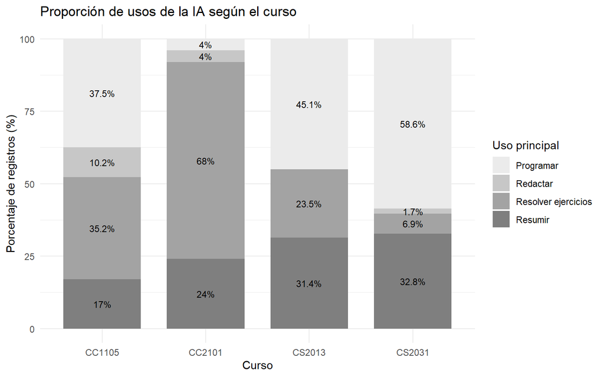

```r
DFC %>%
  count(curso, uso) %>%
  group_by(curso) %>%
  mutate(p = n / sum(n) * 100) %>%
  ggplot(aes(x = curso, y = p, fill = uso)) +
  geom_col(width = 0.75) +
  geom_text(aes(label = paste0(round(p, 1), "%")),
            position = position_stack(vjust = 0.5), size = 3) +
  scale_fill_manual(values = c("gray92", "gray78", "gray64", "gray50")) +
  labs(title = "Proporción de usos de la IA según el curso",
       x = "Curso", y = "Porcentaje de registros (%)", fill = "Uso principal") +
  theme_minimal()
```

### 4.2.4 Objetivo 3b: uso vs. tareas

**Código**

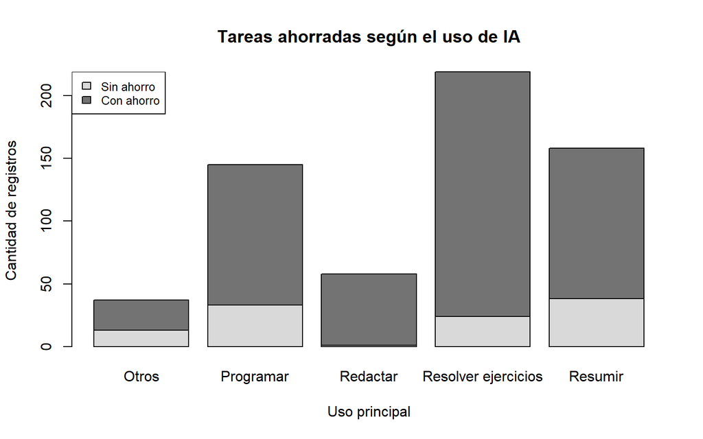

```r
DF3 %>%
  filter(uso_ia == "Usó IA") %>%
  mutate(
    uso_g = if_else(uso %in% c("Resolver ejercicios", "Resumir",
                                "Programar", "Redactar", "No usó IA"),
                     as.character(uso), "Otros"),
    ahorro = if_else(tareas == 0, "Sin tareas ahorradas", "Con tareas ahorradas")
  ) %>%
  count(uso_g, ahorro) %>%
  tidyr::pivot_wider(names_from = ahorro, values_from = n, values_fill = 0) %>%
  {
    tabla <- .[, c("uso_g", "Sin tareas ahorradas", "Con tareas ahorradas")]
    m <- t(as.matrix(tabla[, -1]))
    colnames(m) <- tabla$uso_g
    barplot(m,
            main = "Tareas ahorradas según el uso de IA",
            ylab = "Cantidad de registros",
            xlab = "Uso principal",
            col = c("gray85", "gray45"))
    legend("topleft",
           legend = c("Sin ahorro", "Con ahorro"),
           fill = c("gray85", "gray45"),
           cex = 0.8)
  }
```

**Código**

```r
DF3 %>%
  filter(uso_ia == "Usó IA") %>%
  mutate(uso_g = if_else(uso %in% c("Resolver ejercicios", "Resumir",
                                     "Programar", "Redactar", "No usó IA"),
                          as.character(uso), "Otros")) %>%
  group_by(uso_g) %>%
  summarise(
    registros   = n(),
    ta_ahorrada = round(mean(tareas > 0, na.rm = TRUE) * 100,2)
  ) %>%
  rename(Uso = uso_g)
```

```
# A tibble: 5 × 3
  Uso                 registros ta_ahorrada
  <chr>                   <int>       <dbl>
1 Otros                      37        64.9
2 Programar                 145        77.2
3 Redactar                   58        98.3
4 Resolver ejercicios       219        89.0
5 Resumir                   158        76.0
```

### 4.2.5 Objetivo 4: comprensión vs. sueño

**Código**

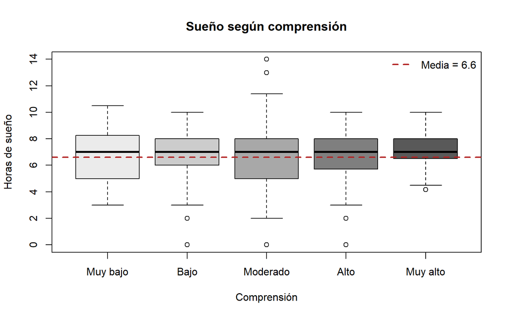

```r
boxplot(sueno ~ comprension, data = DF3,
        main = "Sueño según comprensión",
        xlab = "Comprensión",
        ylab = "Horas de sueño",
        col = c("gray92", "gray80", "gray66", "gray50", "gray35"))
abline(h = mean(DF3$sueno, na.rm = TRUE), col = "firebrick", lwd = 2, lty = 2)
legend("topright",
       legend = paste("Media =", round(mean(DF3$sueno, na.rm = TRUE), 2)),
       col = "firebrick", lty = 2, lwd = 2, bty = "n")
```

**Código**

```r
DF3%>%group_by(comprension)%>% summarise(n=n(),
    Q1= quantile(sueno, 0.25, na.rm = TRUE),
    Mediana = quantile(sueno, 0.5 ,na.rm = TRUE),
    Q3= quantile(sueno, 0.75, na.rm = TRUE),
    RIC     = IQR(sueno, na.rm = TRUE),
    Media = mean(sueno,na.rm=TRUE),
    CV = (sd(sueno,na.rm=TRUE)/mean(sueno,na.rm=TRUE))
                                         )
```

```
# A tibble: 5 × 8
  comprension     n    Q1 Mediana    Q3   RIC Media    CV
  <ord>       <int> <dbl>   <dbl> <dbl> <dbl> <dbl> <dbl>
1 Muy bajo       28   5         7  8.12  3.12  6.66 0.325
2 Bajo           56   6         7  8     2     6.90 0.300
3 Moderado      386   5         7  8     3     6.51 0.313
4 Alto          151   5.7       7  8     2.3   6.53 0.277
5 Muy alto       53   6.5       7  8     1.5   7.13 0.172
```

En Moderado y Alto, que reúnen la mayoría de los registros, el Q1 es 5 y 5.7 horas respectivamente, la mediana 7 y el Q3 8 horas, es decir, el 50% central duerme aproximadamente entre 5 y 8 horas.

El CV se ubica entre 0.17 y 0.33 según el nivel, por lo que la dispersión cambia entre grupos. No se observa una tendencia clara: las medias van de 6.51 h (Moderado) a 7.13 h (Muy alto) sin seguir el orden de la comprensión.

# 5 Análisis Probabilístico

## 5.1 Probabilidad empírica

### 5.1.1 Observaciones limpias del grupo

**Código**

```r
GRUPO <- 6
DF3_grupo <- DF3 %>% filter(Grupo == GRUPO)
nrow(DF3_grupo)
```

```
[1] 166
```

El Grupo 6 aportó 166 observaciones limpias sobre las 674 de la muestra efectiva de la sección.

### 5.1.2 Variable 1: consultas

Se agrupó esta variable en 5 intervalos por los amplios valores que puede tomar, y estos son sin uso, bajo, moderado, frecuente y muy frecuente, donde sin uso corresponde a cero consultas y muy frecuente no tiene límite superior.

**1. Experimento aleatorio:** $EA_1$: seleccionar al azar un registro de la muestra efectiva y observar el nivel de uso de IA según el número de consultas realizadas ese día.

**2. Espacio de resultados:** $\Omega_{EA_1} = \{\text{Sin uso}, \text{Bajo}, \text{Moderado}, \text{Frecuente}, \text{Muy frecuente}\}$, donde Sin uso $= 0$, Bajo $= [1;10]$, Moderado $= [11;20]$, Frecuente $= [21;30]$ y Muy frecuente $= [31;+\infty\rangle$ consultas.

**3. Eventos atómicos:**

$C_i$: seleccionar un registro al azar cuyo nivel de uso de IA sea el $i$-ésimo de $\Omega_{EA_1}$, con $i = 1, 2, 3, 4, 5$.

**4. Cálculo de probabilidades:**

**Código**

```r
consultas_cat <- cut(DF3$consultas,
                     breaks = c(0, 1, 11, 21, 31, Inf),
                     right = FALSE,
                     labels = c("Sin uso", "Bajo", "Moderado",
                                "Frecuente", "Muy frecuente"))

frec_con <- table(consultas_cat)
prob_con <- prop.table(frec_con)
frec_con
```

```
consultas_cat
      Sin uso          Bajo      Moderado     Frecuente Muy frecuente
           61           356           113            67            77
```

**Código**

```r
round(prob_con, 4)
```

```
consultas_cat
      Sin uso          Bajo      Moderado     Frecuente Muy frecuente
       0.0905        0.5282        0.1677        0.0994        0.1142
```

$P(C_1) = 61/674 = 0.0905$; $P(C_2) = 356/674 = 0.5282$; $P(C_3) = 113/674 = 0.1677$; $P(C_4) = 67/674 = 0.0994$; $P(C_5) = 77/674 = 0.1142$.

**5. Validación:**

**Código**

```r
sum(prob_con)
```

```
[1] 1
```

$\sum_{i=1}^{5} P(C_i) = 1$

**Interpretación:**

**Código**

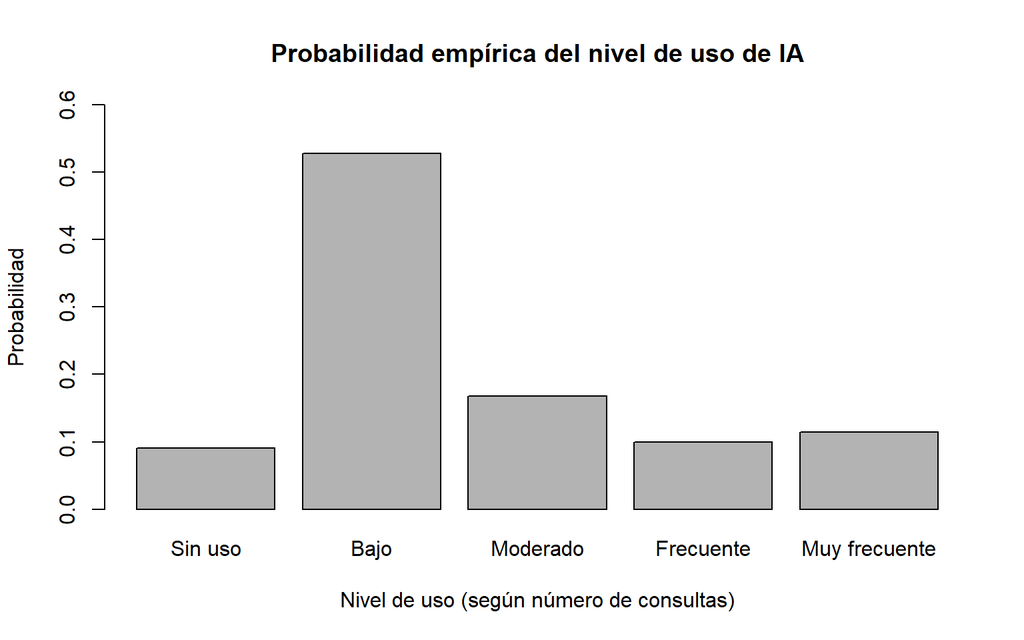

```r
barplot(prob_con,
        main = "Probabilidad empírica del nivel de uso de IA",
        xlab = "Nivel de uso (según número de consultas)",
        ylab = "Probabilidad",
        col = "gray70",
        ylim = c(0, 0.6))
```

El nivel más probable es el bajo, con 0.5282. Las categorías moderado (0.1677), frecuente (0.0994) y muy frecuente (0.1142) se mantienen por debajo de 0.2, y sin uso tiene 0.0905, que corresponde a días sin ninguna consulta a la IA.

### 5.1.3 Variable 2: satisfacción

**1. Experimento aleatorio:** $EA_2$: seleccionar al azar un registro de la muestra efectiva y observar su nivel de satisfacción con el avance académico del día.

**2. Espacio de resultados:** $\Omega_{EA_2} = \{1, 2, 3, 4, 5\}$, donde 1 es muy baja y 5 muy alta.

**3. Eventos atómicos:** $S_i$: seleccionar un registro al azar cuyo nivel de satisfacción sea $i$, con $i = 1, 2, 3, 4, 5$.

**4. Cálculo de probabilidades:**

**Código**

```r
frec_sat <- table(DF3$satisfaccion)
prob_sat <- prop.table(frec_sat)
frec_sat
```

```
  1   2   3   4   5
 49  71 305 186  63
```

**Código**

```r
round(prob_sat, 4)
```

```
     1      2      3      4      5
0.0727 0.1053 0.4525 0.2760 0.0935
```

$P(S_1) = 49/674 = 0.0727$; $P(S_2) = 71/674 = 0.1053$; $P(S_3) = 305/674 = 0.4525$; $P(S_4) = 186/674 = 0.2760$; $P(S_5) = 63/674 = 0.0935$.

**5. Validación:**

**Código**

```r
sum(prob_sat)
```

```
[1] 1
```

$\sum_{i=1}^{5} P(S_i) = 1$

**Interpretación:**

**Código**

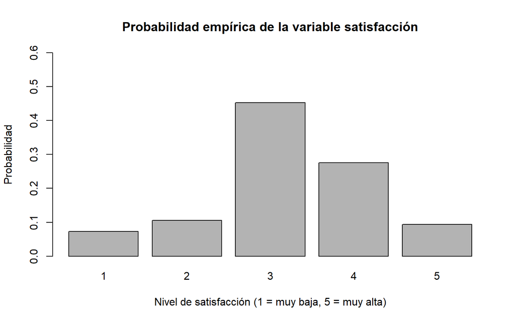

```r
barplot(prob_sat,
        main = "Probabilidad empírica de la variable satisfacción",
        xlab = "Nivel de satisfacción (1 = muy baja, 5 = muy alta)",
        ylab = "Probabilidad",
        col = "gray70",
        ylim = c(0, 0.6))
```

El nivel más probable es 3, con 0.4525. La probabilidad de una satisfacción alta (4 o 5) es 0.3694, aproximadamente el doble que la de una baja (1 o 2), que es 0.1780.

## 5.2 Probabilidad condicional

### 5.2.1 Eventos de interés

Se eligió el rango [5,15] ya que se evita la alta frecuencia que hay en [0,5] y se prioriza una buena cantidad de datos.

Vamos a ver la probabilidad del evento A dado el evento B

Evento A : Seleccionar un registro al azar cuyo nivel de comprensión sea de `Alto`.

Evento B : Seleccionar un registro al azar cuyo número de consultas a la IA esté en el rango [5, 15]

**Código**

```r
P_A = nrow(DF3 %>% filter(comprension == "Alto")) / nrow(DF3)
paste("Probabilidad de A:", P_A)
```

```
[1] "Probabilidad de A: 0.224035608308605"
```

**Código**

```r
P_B = nrow(DF3 %>% filter(5 <= consultas & consultas <= 15)) / nrow(DF3)
paste("Probabilidad de B:", P_B)
```

```
[1] "Probabilidad de B: 0.376854599406528"
```

### 5.2.2 Validación de independencia

**Código**

```r
P_A_dado_B = nrow(DF3 %>% filter(5 <= consultas & consultas <= 15 & comprension == "Alto")) / nrow(DF3 %>% filter(5 <= consultas & consultas <= 15))

P_B_dado_A = nrow(DF3 %>% filter(5 <= consultas & consultas <= 15 & comprension == "Alto")) / nrow(DF3 %>% filter(comprension == "Alto"))

P_B_dado_noA = nrow(DF3 %>% filter(5 <= consultas & consultas <= 15 & comprension != "Alto")) / nrow(DF3 %>% filter(comprension != "Alto"))

P_A_dado_B
```

```
[1] 0.2125984
```

**Código**

```r
P_A_inter_B<- nrow(DF3 %>% filter(5 <= consultas & consultas <= 15 & comprension == "Alto")) / nrow(DF3)
P_A_inter_B == P_A * P_B
```

```
[1] FALSE
```

**Código**

```r
round(P_A_inter_B,4) == round(P_A* P_B,4)
```

```
[1] FALSE
```

**Código**

```r
P_A_dado_B==P_A
```

```
[1] FALSE
```

$P(A \cap B)=0.0801$ y $P(A)\cdot P(B)=0.0844$.

$P(A \cap B) \neq P(A) \cdot P(B)$ para los datos de la muestra, por lo cual los eventos no son exactamente independientes en la distribución empírica. La diferencia es pequeña y no permite asegurar dependencia en toda la población.

**Código**

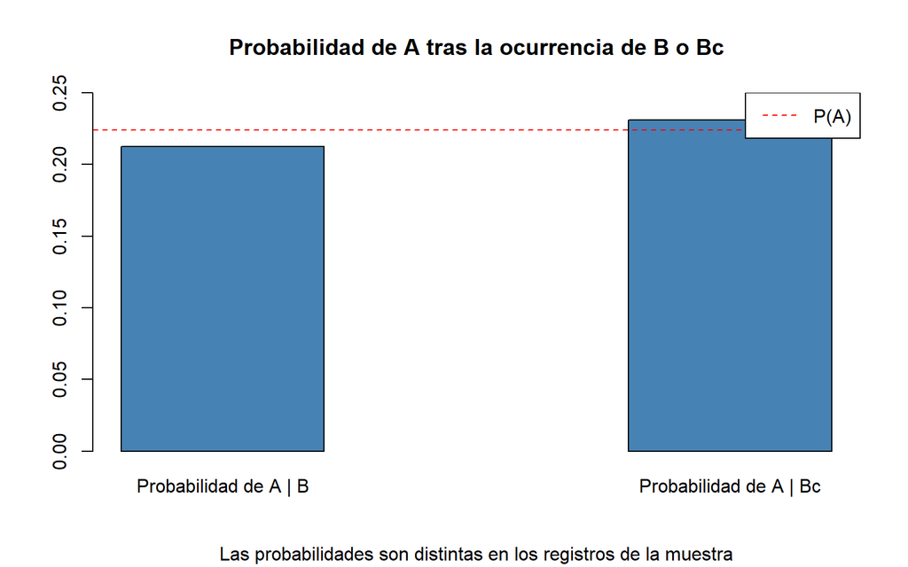

```r
P_A_dado_noB <- nrow(DF3 %>% filter(comprension == "Alto", consultas < 5 | consultas > 15)) /
  nrow(DF3 %>% filter(consultas < 5 | consultas > 15))

barplot(c(P_A_dado_B, P_A_dado_noB),
        main = "Probabilidad de A tras la ocurrencia de B o Bc",
        names.arg = c("Probabilidad de A | B", "Probabilidad de A | Bc"),
        col = "steelblue",
        sub = "Las probabilidades son distintas en los registros de la muestra",
        ylim = c(0, 0.25),
        space = 1.5)
abline(h = P_A, col = "red", lty = 2)
legend("topright", legend = "P(A)", col = "red", lty = 2)
```

### 5.2.3 Probabilidad condicional y propiedades

Se clasifican los eventos simples $A$ (nivel de comprensión `Alto`) y $B$ (consultas en $[5, 15]$), junto con sus eventos compuestos asociados y complementos. Aplicando las propiedades de probabilidad:

**Código**

```r
P_A_U_B<-P_A+P_B-P_A_inter_B
P_A_comp<-1-P_A
P_B_comp<-1-P_B

P_A = nrow(DF3 %>% filter(comprension == "Alto")) / nrow(DF3)

P_B = nrow(DF3 %>% filter(5 <= consultas & consultas <= 15)) / nrow(DF3)

#leyes de morgan

P_A_U_B_comp<-1-P_A_U_B
P_A_inter_B_comp<-1-P_A_inter_B
P_A_U_B
```

```
[1] 0.5207715
```

**Código**

```r
P_A_comp
```

```
[1] 0.7759644
```

**Código**

```r
P_B_comp
```

```
[1] 0.6231454
```

**Código**

```r
P_A_U_B_comp
```

```
[1] 0.4792285
```

**Código**

```r
P_A_inter_B_comp
```

```
[1] 0.9198813
```

**Código**

```r
P_A_dif_B<-P_A-P_A_inter_B
P_A_dif_B
```

```
[1] 0.1439169
```

**Código**

```r
P_B_dif_A<-P_B-P_A_inter_B
P_B_dif_A
```

```
[1] 0.2967359
```

**Código**

```r
P_A_dif_Sim_B<-P_A_U_B - P_A_inter_B
P_A_dif_Sim_B
```

```
[1] 0.4406528
```

**Código**

```r
P_A_d_B<-P_A_inter_B/P_B
P_A_d_B
```

```
[1] 0.2125984
```

**Código**

```r
P_A_inter_B
```

```
[1] 0.08011869
```

Los eventos de interés son A y B; el resto son sus combinaciones y complementos.

- **Unión:** $P(A \cup B) = P(A) + P(B) - P(A \cap B) = 0.2240 + 0.3769 - 0.0801 = 0.5208$

Este primer resultado indica que el $52.08\%$ de los registros de la jornada presentan una comprensión alta, un número de consultas entre 5 y 15, o ambas condiciones simultáneamente.

- **Complementos:** $P(A^c) = 1 - P(A) = 0.7760 \quad \text{y} \quad P(B^c) = 1 - P(B) = 0.6231$
- **Leyes de De Morgan (Complemento de la Unión e Intersección):**
  $$P((A \cup B)^c) = 1 - P(A \cup B) = 0.4792, \qquad P((A \cap B)^c) = 1 - P(A \cap B) = 0.9199$$
- **Intersección:**
  $$P(A \cap B)=0.08011869$$
- **Diferencia:**

$$P(A \setminus B) = P(A) - P(A \cap B) = 0.1439$$

$$P(B \setminus A) = P(B) - P(A \cap B) = 0.2967$$

- **Diferencia simétrica:**

$$P(A \triangle B) = P(A \cup B) - P(A \cap B) = 0.4407$$

- **Regla del producto:**

$P(A \cap B) = P(A) * P(B|A)=$ 0.2240356 * 0.3576159 = 0.0801187

$P(A \cap B) = P(B) * P(A|B)=$ 0.3768546 * 0.2125984 = 0.0801187

- **Probabilidad total:**

$P(B) = P(B|A) * P(A) + P(B|A^c) * P(A^c) =$ 0.3576 * 0.224 + 0.3824 * 0.776 = 0.3768546

$P(A) = P(A|B) * P(B) + P(A|B^c) * P(B^c) =$ 0.2126 * 0.3769 + 0.231 * 0.6231 = 0.2240356

### 5.2.4 Teorema de Bayes

Aplicando el Teorema de Bayes para calcular la probabilidad del nivel de comprensión `Alto` ($A$) dado que las consultas están en el rango $[5, 15]$ ($B$):

$$P(A|B) = \frac{P(B|A) \cdot P(A)}{P(B|A) \cdot P(A) + P(B|A^c) \cdot P(A^c)} = 0.2125984$$

**Código**

```r
P_B_dado_A
```

```
[1] 0.3576159
```

**Código**

```r
P_B_dado_noA
```

```
[1] 0.3824092
```

Entonces, el valor obtenido por medio del Teorema de Bayes expandido es:

**Código**

```r
( P_B_dado_A * P_A ) / ( P_B_dado_A * P_A + P_B_dado_noA * P_A_comp)
```

```
[1] 0.2125984
```

Mientras que el resultado del cálculo directo es:

**Código**

```r
P_A_dado_B
```

```
[1] 0.2125984
```

Los cálculos se realizaron adecuadamente, pues los resultados coinciden.

### 5.2.5 Interpretación en el contexto del estudio

De los resultados del Teorema de Bayes se aprecia que la probabilidad de que el nivel de compresión sea `Alto` dado que la cantidad de consultas a la IA está en el intervalo [5, 15] es de 21.26%. Esto indicaría que es más probable obtener un nivel de comprensión distinto de `Alto` cuando se utiliza un número de consultas contenido en el rango [5, 15].

## 5.3 Variables aleatorias discretas

### 5.3.1 Variable aleatoria discreta 1

**Código**

```r
exito <- DF3$consultas > 20
p <- mean(exito)
q <- 1 - p
```

**1. Caso:** Se revisan registros de la muestra efectiva al azar, uno tras otro, con reposición. Un éxito es un registro con más de 20 consultas a la IA. ¿Cuál es la probabilidad de que el primer éxito sea exactamente el quinto registro?

**2. Distribución teórica:** Sea $X$ el número de registros revisados hasta encontrar el primero con más de 20 consultas a la IA. Entonces $X\sim Geom(p)$ con soporte $\{1,2,3,\dots\}$, donde $p$ es la probabilidad de seleccionar un registro con más de 20 consultas. Con los datos, $p=$ 144$/$674 $=$ 0.2136.

**3. Descripción de la distribución:** $P(X=k)=(1-p)^{k-1}p$. Es estrictamente decreciente para todo $k\ge1$, por lo que la moda es siempre $k=1$. Como $p<0.5$, la probabilidad se dispersa hacia la derecha con cola larga y el valor esperado supera 2.

**4. Propiedades:**

- $E(X)=\frac{1}{p}=$ 4.68 registros.
- $Var(X)=\frac{1-p}{p^2}=$ 17.23 y $\sigma=$ 4.15.
- $CV=\frac{\sigma}{E(X)}=\sqrt{1-p}=$ 0.8868.
- Falta de memoria: $P(X>m+n\mid X>m)=P(X>n)$.

**5. Respuesta del caso:** $P(X=5)=$ 0.0817. Hay una probabilidad de 8.17% de que el primer registro con más de 20 consultas sea el quinto.

**6. Distribución acumulada:** $F(k)=1-(1-p)^k$. Por ejemplo, ¿cuál es la probabilidad de que baste revisar 5 registros o menos para encontrar el primer éxito? $P(X\le5)=$ 0.6993, es decir, 69.93% de los casos.

**Evidencia con los datos:**

**Código**

```r
N <- length(exito)
k_all <- 1:N
pmf <- dgeom(k_all - 1, p)
cdf_izq <- pgeom(k_all - 1, p)        # P(X <= k)
cdf_der <- q^(k_all - 1)              # P(X >= k)
sum(pmf)                              # validación: ≈ 1
```

```
[1] 1
```

**Código**

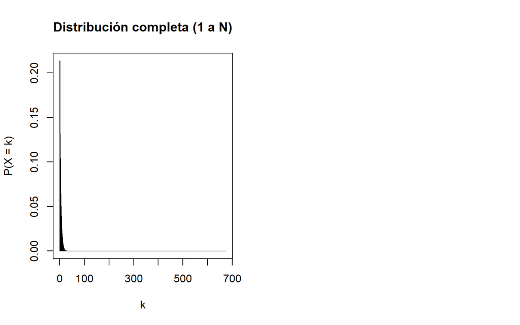

```r
set.seed(6)
seleccion_geo <- sample(exito, size = 3000, replace = TRUE)
espera <- diff(c(0, which(seleccion_geo)))
ks <- 1:20
emp <- sapply(ks, function(i) mean(espera == i))

par(mfrow = c(1, 2))

# Distribución completa (1 a N)
plot(k_all, pmf, type = "h", xlab = "k", ylab = "P(X = k)",
     main = "Distribución completa (1 a N)")
```

**Código**

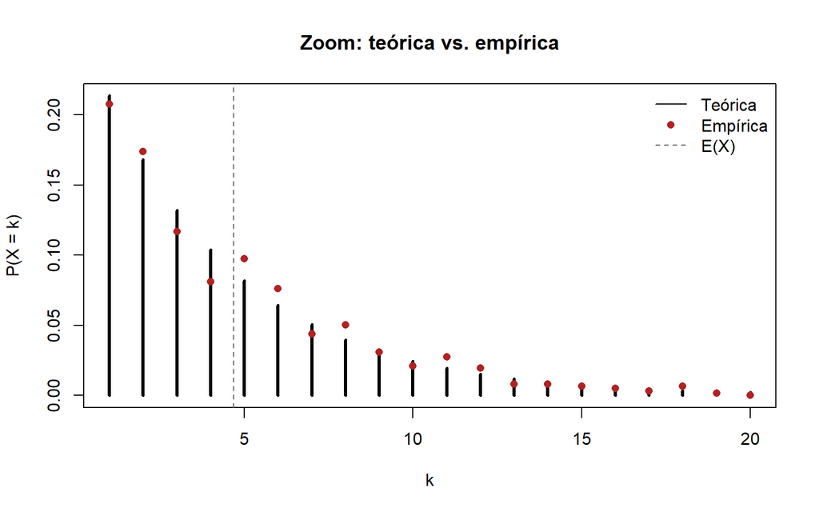

```r
# Zoom: teórica vs. empírica
plot(ks, pmf[ks], type = "h", lwd = 3, xlab = "k", ylab = "P(X = k)",
     ylim = c(0, max(pmf[ks], emp)),
     main = "Zoom: teórica vs. empírica")
points(ks, emp, pch = 16, col = "firebrick")
abline(v = 1/p, lty = 2, col = "gray40")
legend("topright", legend = c("Teórica", "Empírica", "E(X)"),
       lty = c(1, NA, 2), pch = c(NA, 16, NA),
       col = c("black", "firebrick", "gray40"), bty = "n")
```

**Código**

```r
par(mfrow = c(1, 1))
```

**Código**

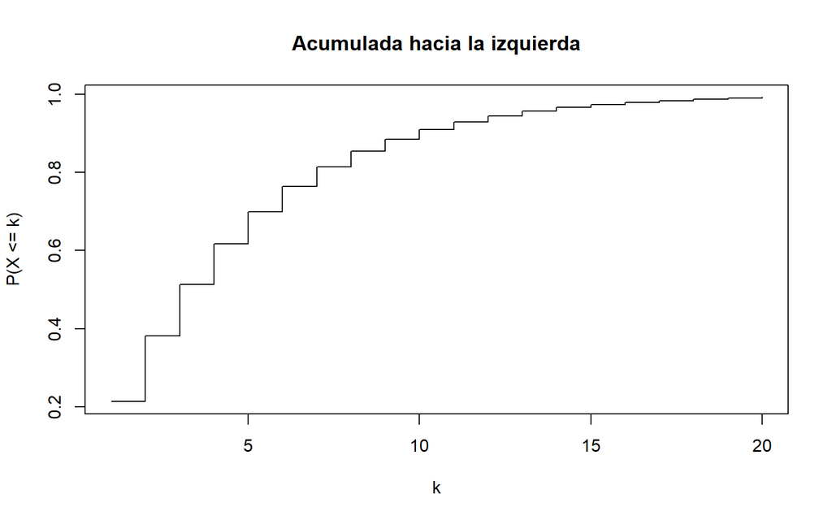

```r
# Acumulada hacia la izquierda
plot(ks, cdf_izq[ks], type = "s", xlab = "k", ylab = "P(X <= k)",
     main = "Acumulada hacia la izquierda")
```

**Código**

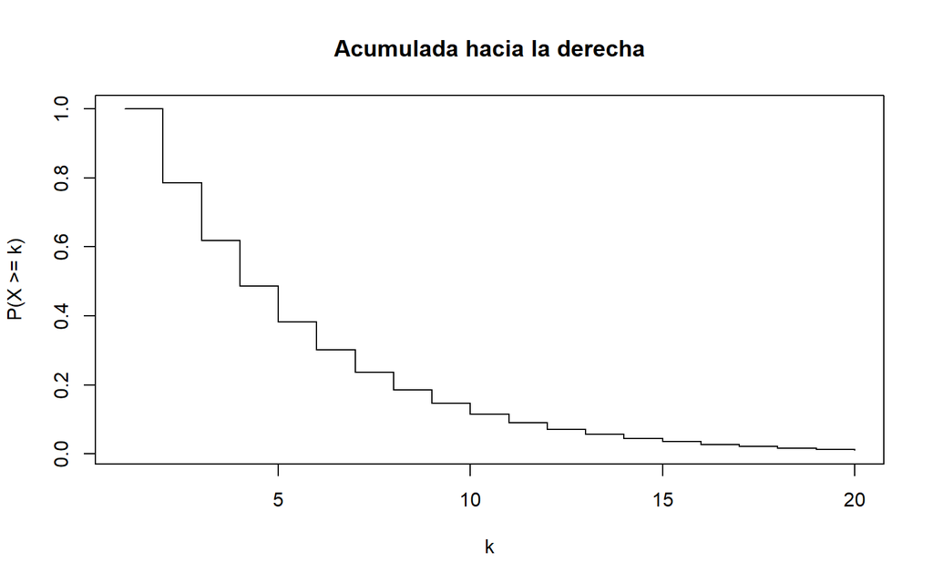

```r
# Acumulada hacia la derecha
plot(ks, cdf_der[ks], type = "s", xlab = "k", ylab = "P(X >= k)",
     main = "Acumulada hacia la derecha")
```

**Código**

```r
data.frame(k = ks, `P(X=k)` = round(pmf[ks], 4), empirica = round(emp, 4),
           `P(X<=k)` = round(cdf_izq[ks], 4), `P(X>=k)` = round(cdf_der[ks], 4),
           check.names = FALSE)
```

```
    k P(X=k) empirica P(X<=k) P(X>=k)
1   1 0.2136   0.2078  0.2136  1.0000
2   2 0.1680   0.1737  0.3817  0.7864
3   3 0.1321   0.1169  0.5138  0.6183
4   4 0.1039   0.0812  0.6176  0.4862
5   5 0.0817   0.0974  0.6993  0.3824
6   6 0.0642   0.0763  0.7636  0.3007
7   7 0.0505   0.0438  0.8141  0.2364
8   8 0.0397   0.0503  0.8538  0.1859
9   9 0.0312   0.0308  0.8850  0.1462
10 10 0.0246   0.0211  0.9096  0.1150
11 11 0.0193   0.0276  0.9289  0.0904
12 12 0.0152   0.0195  0.9441  0.0711
13 13 0.0119   0.0081  0.9560  0.0559
14 14 0.0094   0.0081  0.9654  0.0440
15 15 0.0074   0.0065  0.9728  0.0346
16 16 0.0058   0.0049  0.9786  0.0272
17 17 0.0046   0.0032  0.9832  0.0214
18 18 0.0036   0.0065  0.9868  0.0168
19 19 0.0028   0.0016  0.9896  0.0132
20 20 0.0022   0.0000  0.9918  0.0104
```

Las esperas simuladas entre registros con más de 20 consultas tienen media 4.85, frente a $E(X)=$ 4.68.

### 5.3.2 Variable aleatoria discreta 2

**1. Caso:** Se desea conocer la probabilidad de que, al seleccionar al azar 10 registros del estudio con reposición, exactamente 3 correspondan a días en los que la IA ahorró tiempo en 3 o más tareas. Elegimos este éxito porque la mayoría de registros tiene entre 0 y 2 tareas, así que 3 o más representa un día de uso intensivo de la IA.

**2. Distribución teórica:**

**Código**

```r
n_tar <- 10
p_tar <- mean(DF3$tareas >= 3)
p_tar
```

```
[1] 0.2225519
```

X: número de registros, de 10 seleccionados al azar, en los que la IA ahorró tiempo en 3 o más tareas.

$X \sim Bin(n = 10,\ p = 0.2226)$, donde p = P(seleccionar un registro con 3 o más tareas en las que la IA ahorró tiempo).

**3. Descripción de la distribución:** $P(X=k)=\binom{n}{k} p^k(1-p)^{n-k}$. Es una distribución que por tener $p<0.5$ presenta una cola hacia la derecha. Además, el valor esperado supera 2.

**4. Propiedades:**

**Código**

```r
E_tar <- n_tar * p_tar
V_tar <- n_tar * p_tar * (1 - p_tar)
SD_tar <- sqrt(V_tar)
CV_tar <- SD_tar / E_tar
```

$E(X) = np = 2.23$, $V(X) = np(1-p) = 1.73$, $SD(X) = 1.32$ y $CV(X) = 0.59$. Es decir, de cada 10 registros se esperan unos 2 con 3 o más tareas con ahorro de tiempo.

**5. Respuesta del caso:**

**Código**

```r
dbinom(3, n_tar, p_tar)
```

```
[1] 0.227078
```

$P(X = 3) = 0.2271$: hay un 22.71% de probabilidad de que exactamente 3 de los 10 registros tengan 3 o más tareas con ahorro de tiempo.

**6. Distribución acumulada:**

P(X ≤ 2): probabilidad de que, de 10 registros, como máximo 2 tengan 3 o más tareas con ahorro de tiempo.

**Código**

```r
pbinom(2, n_tar, p_tar)
```

```
[1] 0.6090691
```

$P(X \leq 2) = 0.6091$, por lo que en más de la mitad de los casos habrá como máximo 2 días de uso intensivo entre 10 registros.

**Evidencia con los datos:** seleccionamos registros con reposición, formamos grupos de 10 y contamos en cada grupo cuántos tienen 3 o más tareas, para compararlo con el modelo.

**Código**

```r
set.seed(6)
n_grupos <- 1000
mezcla <- sample(DF3$tareas, size = n_grupos * n_tar, replace = TRUE)
grupos <- matrix(mezcla >= 3, nrow = n_tar)
exitos <- colSums(grupos)
mean(exitos)
```

```
[1] 2.206
```

**Código**

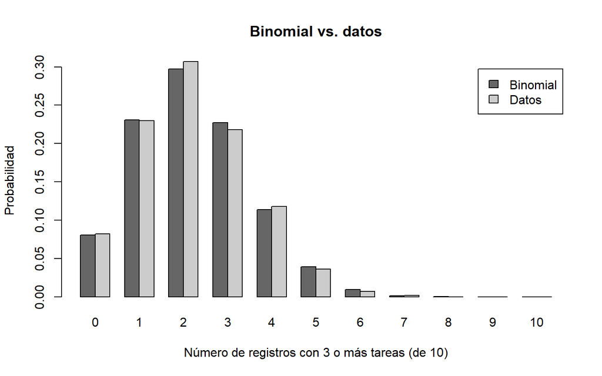

```r
teorica <- dbinom(0:10, n_tar, p_tar)
empirica <- table(factor(exitos, levels = 0:10)) / length(exitos)

barplot(rbind(teorica, empirica),
        beside = TRUE,
        names.arg = 0:10,
        col = c("gray40", "gray80"),
        legend.text = c("Binomial", "Datos"),
        main = "Binomial vs. datos",
        xlab = "Número de registros con 3 o más tareas (de 10)",
        ylab = "Probabilidad")
```

En 1000 grupos de 10 registros seleccionados con reposición, el promedio de éxitos es 2.21, cerca del valor esperado del modelo (2.23). Además, las barras del modelo y de la simulación tienen una forma similar.

Acá presentamos la gráfica completa de la distribución teórica

**Código**

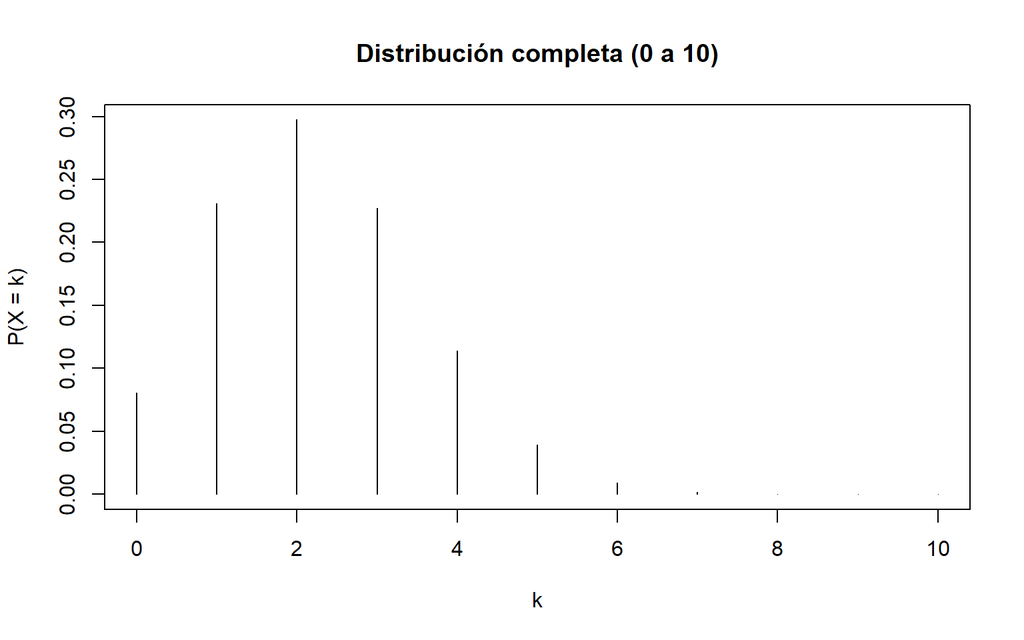

```r
k_all <- 0:n_tar
pmf <- dbinom(k_all, n_tar, p_tar)

par(mfrow = c(1, 1))

# Distribución completa (0 a 10)
plot(k_all, pmf, type = "h", xlab = "k", ylab = "P(X = k)",
     main = "Distribución completa (0 a 10)")
```

## 5.4 Variables aleatorias continuas

**1. Variable de estudio:**

Horas de sueño

**2. Validación de la distribución:**

**Código**

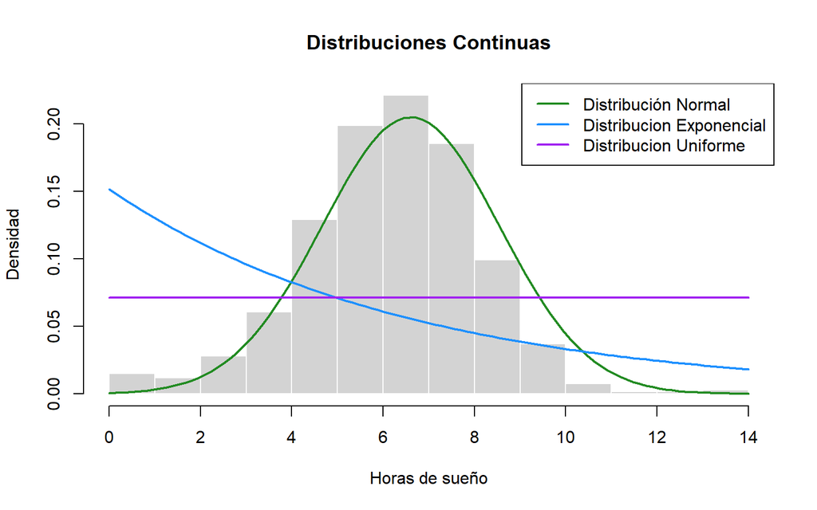

```r
#Datos basicos
media_ <- mean(DF3$sueno,na.rm=TRUE)
mediana_<-median(DF3$sueno,na.rm=TRUE)
var_<-var(DF3$sueno,na.rm=TRUE)
sd_ <- sd(DF3$sueno,na.rm=TRUE)
lambda_ <- 1 / media_
min_ <- min(DF3$sueno,na.rm=TRUE)
max_ <- max(DF3$sueno,na.rm=TRUE)

cv_<-(sd_/media_)*100

# con probability= TRUE sirve para el cambio de escala para que represente la densidad de probabilidad

hist(DF3$sueno, probability = TRUE, col = "lightgray", border = "white",
     main = "Distribuciones Continuas",
     xlab = "Horas de sueño", ylab = "Densidad" )

# Normal

#el uso de dnorm() es la funcion de densidad de la probabilidad normal el cual usa x que es la variable independiente, despues el caso de from y to definen los limites de calculo y dibujo

curve(dnorm(x, mean = media_, sd = sd_), col = "forestgreen", lwd = 2, add = TRUE, from = min_, to = max_)

# Exponencial

# el uso de lambda es debido a la teoria que relaciona la media y la tasa

curve(dexp(x, rate = lambda_), col = "dodgerblue", lwd = 2, add = TRUE, from = min_, to = max_)

# Uniforme

# El uso de min y max es debido a la propia formula de la densidad de probabilidad

curve(dunif(x, min = min_, max = max_), col = "purple", lwd = 2, add = TRUE, from = min_, to = max_)

legend("topright", legend = c("Distribución Normal", "Distribucion Exponencial", "Distribucion Uniforme"),
       col = c("forestgreen", "dodgerblue","purple"), lty=1, lwd=2)
```

Para la curva normal se deberá comprobar en este caso la simetría

$mediana=$ 7

$media=$ 6.6003294

La simetría no es exacta, por lo que se usará la normal solo como aproximación.

Para la curva exponencial se deberá revisar el cv, que debería de ser 100

**Código**

```r
cv_
```

```
[1] 29.49941
```

$$CV=29.49941$$

No es 100, entonces se descarta la exponencial

Para la distribución uniforme se deberá revisar si el rango de datos es aproximadamente 3.464 veces la desviación estándar muestral y comprobar las varianzas

**Código**

```r
max_-min_
```

```
[1] 14
```

**Código**

```r
sd_*sqrt(12)
```

```
[1] 6.744807
```

**Código**

```r
sd_^2
```

```
[1] 3.791035
```

**Código**

```r
((max_-min_)^2)/12
```

```
[1] 16.33333
```

Comparación de varianza teórica con la empírica

$$\frac{(max - min)^2}{12} = 16.33333$$

$$sd^2 = 3.791035$$

Relación rango con desviación estándar

$$max-min=14$$

$$sd\cdot \sqrt{12} = 6.744807$$

Como la varianza teórica no es similar a la empírica y también la relación rango con la desviación estándar tampoco cumple por lo que se descarta

**3. Propiedades:**

Se tendrá en cuenta en este caso la distribución normal como aproximación debido a la gráfica y a que la media está cerca de la mediana.

**Código**

```r
sd_
```

```
[1] 1.947058
```

**Código**

```r
media_
```

```
[1] 6.600329
```

Por lo que el modelo propuesto será:

$$N(\mu=6.600329,\sigma=1.947058)$$

**Código**

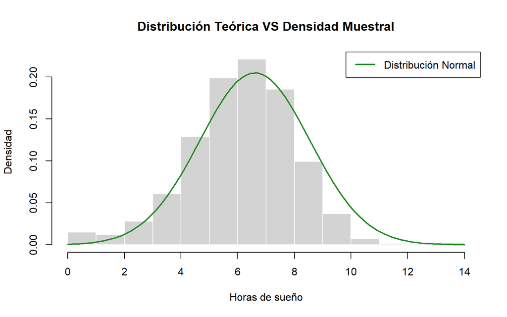

```r
hist(DF3$sueno, probability = TRUE, col = "lightgray", border = "white",
     main = "Distribución Teórica VS Densidad Muestral",
     xlab = "Horas de sueño", ylab = "Densidad" )

curve(dnorm(x, mean = media_, sd = sd_), col = "forestgreen", lwd = 2, add = TRUE, from = min_, to = max_)

legend("topright", legend = c("Distribución Normal"),
       col = c("forestgreen"), lty=1, lwd=2)
```

**4. Ejemplo:**

¿Cual es la probabilidad de que un estudiante duerma 4 horas o menos?

Probabilidad Teórica:

**Código**

```r
prob_4_teo<-pnorm(q=4,mean=media_, sd=sd_)
prob_4_teo
```

```
[1] 0.09085359
```

$$probTeorica=0.0908536$$

Probabilidad Empírica:

**Código**

```r
prob_4_empirica<-mean(DF3$sueno<=4,na.rm=TRUE)
prob_4_empirica
```

```
[1] 0.115727
```

**Código**

```r
prob_4_empirica-prob_4_teo
```

```
[1] 0.02487342
```

$$proEmpirica=0.115727$$

Hay una diferencia de 0.0248734, por lo que el modelo sirve como aproximación de los datos.

### 5.4.1 Variable aleatoria continua 2

**1. Variable de estudio:** `Horas de estudio`

**2. Validación de la distribución:**

**Código**

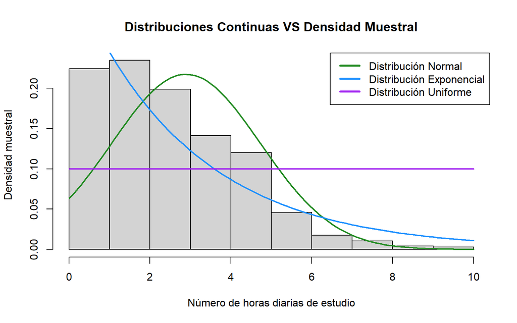

```r
estudio <- DF3$estudio

media_estudio <- mean(estudio, na.rm = TRUE)
min_estudio <- min(estudio, na.rm = TRUE)
max_estudio <- max(estudio, na.rm = TRUE)
prom_estudio <- mean(estudio, na.rm = TRUE)
std_estudio <- sd(estudio, na.rm = TRUE)
lambda_estudio <- 1 / media_estudio

hist(estudio, probability = TRUE,
     main = "Distribuciones Continuas VS Densidad Muestral",
     xlab = "Número de horas diarias de estudio", ylab = "Densidad muestral")

# Normal
curve(dnorm(x, mean = media_estudio, sd = std_estudio), col = "forestgreen", lwd = 2, add = TRUE, from = min_estudio, to = max_estudio)

# Exponencial
curve(dexp(x, rate = lambda_estudio), col = "dodgerblue", lwd = 2, add = TRUE, from = min_estudio, to = max_estudio)

# Uniforme
curve(dunif(x, min = min_estudio, max = max_estudio), col = "purple", lwd = 2, add = TRUE, from = min_estudio, to = max_estudio)

legend("topright", legend = c("Distribución Normal", "Distribución Exponencial", "Distribución Uniforme"),
       col = c("forestgreen", "dodgerblue", "purple"), lwd = c(3, 3, 3), lty = c(1, 1, 1))
```

**Código**

```r
paste("Esperanza Uniforme:", (min_estudio + max_estudio) / 2)
```

```
[1] "Esperanza Uniforme: 5"
```

**Código**

```r
paste("Promedio Muestral:", prom_estudio)
```

```
[1] "Promedio Muestral: 2.88948071216617"
```

**Código**

```r
paste("Varianza Uniforme:", (max_estudio - min_estudio)^2 / 12)
```

```
[1] "Varianza Uniforme: 8.33333333333333"
```

**Código**

```r
paste("Varianza Muestral:", std_estudio^2)
```

```
[1] "Varianza Muestral: 3.37330448476859"
```

Tanto el promedio como la varianza difieren enormemente entre los predicho por la distribución teórica y lo obtenido en la muestra. Por lo tanto, descartamos la distribución uniforme como aproximación.

**Código**

```r
median(estudio, na.rm = T)
```

```
[1] 3
```

**Código**

```r
prom_estudio
```

```
[1] 2.889481
```

Si bien la media y la mediana de la muestra se acercan bastante, la gráfica hace notar una gran asimetría en su distribución. Por lo tanto, descartamos la distribución normal como aproximación.

**Código**

```r
paste("Esperanza Exponencial:", 1 / lambda_estudio)
```

```
[1] "Esperanza Exponencial: 2.88948071216617"
```

**Código**

```r
paste("Promedio Muestral:", prom_estudio)
```

```
[1] "Promedio Muestral: 2.88948071216617"
```

**Código**

```r
paste("Varianza Exponencial:", 1 / lambda_estudio^2)
```

```
[1] "Varianza Exponencial: 8.34909878598033"
```

**Código**

```r
paste("Varianza Muestral:", std_estudio^2)
```

```
[1] "Varianza Muestral: 3.37330448476859"
```

La varianza teórica y la muestral son diferentes, por lo que la exponencial no es un ajuste exacto. Sin embargo, como la variable es no negativa y tiene más registros con pocas horas, se utilizará como aproximación: $estudio \sim Exp(\lambda = 0.346083)$, donde $\lambda = 1/\bar{x}$ es la tasa y no la media.

**Código**

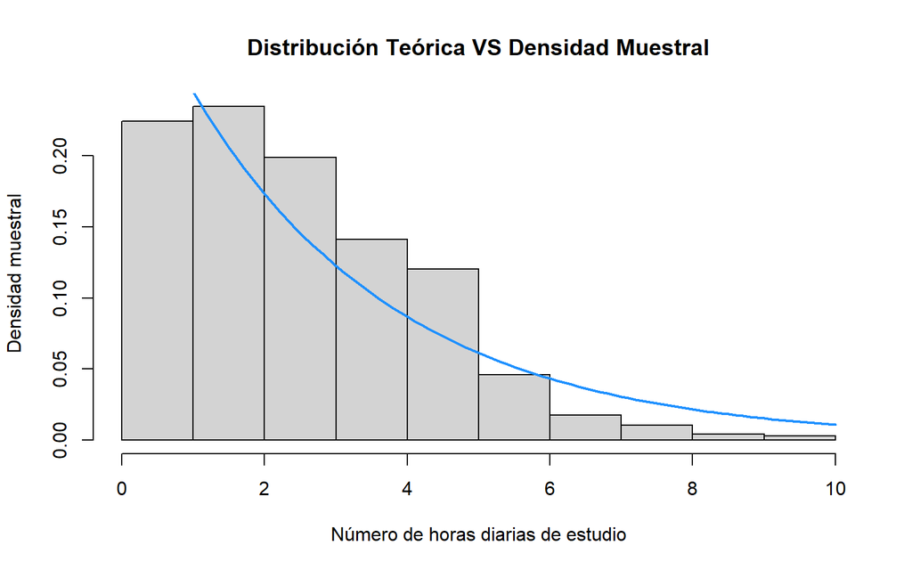

```r
hist(estudio, probability = TRUE,
     main = "Distribución Teórica VS Densidad Muestral",
     xlab = "Número de horas diarias de estudio", ylab = "Densidad muestral")

# Exponencial
curve(dexp(x, rate = lambda_estudio), col = "dodgerblue", lwd = 2, add = TRUE, from = min_estudio, to = max_estudio)
```

**3. Propiedades:**

$$\begin{cases}
E(estudio) = 1 / \lambda = 2.889481 \\
V(estudio) = 1 / \lambda^2 = 8.349099 \\
SD(estudio) = 1 / \lambda = 2.889481 \\
CV(estudio) = \frac{SD(estudio)}{|E(estudio)|} = 1
\end{cases}$$

**4. Ejemplo:**

¿Cuál es la probabilidad de que un registro reporte más de 5 horas de estudio y a lo mucho 8 horas?

**Código**

```r
v1 <- pexp(8, lambda_estudio) - pexp(5, lambda_estudio)
v1
```

```
[1] 0.1144651
```

**Código**

```r
v2 <- nrow(DF3 %>% filter(5 < estudio & estudio <= 8)) / nrow(DF3)
v2
```

```
[1] 0.07418398
```

Comparando la respuesta obtenida desde el modelo exponencial (11.45%) y aquella obtenida directamente desde la muestra (7.42%), se nota una diferencia de 0.0403. Por eso se toma la exponencial como aproximación y no como un ajuste exacto.

# 6 Conclusiones

## 6.1 Conclusión de la primera parte del estudio

Después de limpiar los datos, vimos que los estudiantes de Estadística sección 1 usan la IA casi todos los días y para cosas distintas según el curso. Los que hacen más consultas suelen estudiar más horas y sentirse más satisfechos con su avance. En cambio, las horas de sueño casi no cambian según el nivel de comprensión. Esto no prueba que una cosa cause la otra, solo que suelen darse juntas.

## 6.2 Conclusión de probabilidad

El análisis empírico evidencia que los estudiantes de la sección tienen un predominante uso bajo de la Inteligencia artificial. Por un lado, el $52.82\%$ realiza entre 1 y 10 consultas diarias y el $45.25\%$ reporta un nivel intermedio de satisfacción académica (un nivel 3). Asimismo, el análisis condicional muestra una diferencia pequeña entre hacer $[5, 15]$ consultas y una alta comprensión académica ($P(A \cap B) \neq P(A)P(B)$), registrando una probabilidad condicional del $P(A|B) = 21.26\%$. Esto sugiere que hacer un número intermedio de consultas no asegura una comprensión máxima, sino que es más bien un hábito dentro de la rutina de estudio del estudiante.

## 6.3 Conclusión de variables aleatorias

La VA discreta 1 nos muestra que, revisando 5 registros o menos con reposición, hay más del 60% de probabilidad de encontrar uno que reporte más de 20 consultas a la IA. Este resultado nos habla sobre la intensidad en el uso de la IA en varios registros, aunque no permite inferir por sí solo su importancia para todos los universitarios.